# Unemployment in Chicago

Melanie McCord

2023-05-03

# Introduction

## Motivation

The purpose of this project was to explore unemployment in Chicago and to understand how it changed in relation to the pandemic. The unemployment rate can be affected by the economy, growth in different sectors, as well as other factors. However, the pandemic resulted in major changes to our way of lives, due to closing of in-person events, resulting in major economic changes. In order to understand these trends and how drastic they were, for my project, I chose to explore the unemployment rate in Chicago.

## Dataset

This dataset comes from the non-seasonally adjusted Chicago unemployment metrics from the US bureau of statistics. The period of the data is monthly. I chose to focus on Chicago specifically because the city of Chicago publishes a great deal of metrics and future work aims to extend the analysis of this data into other variables. The time period of the dataset goes from January 1994 to January 2023.

# Data Exploration

```r
unemployment_chicago <- readxl::read_excel("data/Chicago-Naperville-ArlingtonHeights_MD_notseasadj.xls", skip = 6) %>%
  drop_na() %>%
  rename(Month = `Month/Year`) %>%
  mutate(`Month` = yearmonth(Month)) %>%
  as_tsibble(index = Month)
head(unemployment_chicago)
```

```
## # A tsibble: 6 x 8 [1M]
##      Month `Labor Force` Labor Force Participa…¹ Employed EmploymentParticipat…²
##      <mth>         <dbl>                   <dbl>    <dbl>                  <dbl>
## 1 1994 Jan       3489100                    67.9  3207300                   62.4
## 2 1994 Feb       3504900                    68.2  3241900                   63
## 3 1994 Mar       3483800                    67.7  3237500                   62.9
## 4 1994 Apr       3473900                    67.5  3246100                   63.1
## 5 1994 May       3510600                    68.2  3300400                   64.1
## 6 1994 Jun       3566400                    69.2  3338500                   64.8
## # ℹ abbreviated names: ¹`Labor Force Participation Rate`,
## #   ²`EmploymentParticipation Rate`
## # ℹ 3 more variables: Unemployed <dbl>, `Unemployment Rate` <dbl>,
## #   `IL Rate` <dbl>
```

The data is seasonal, in this case monthly.

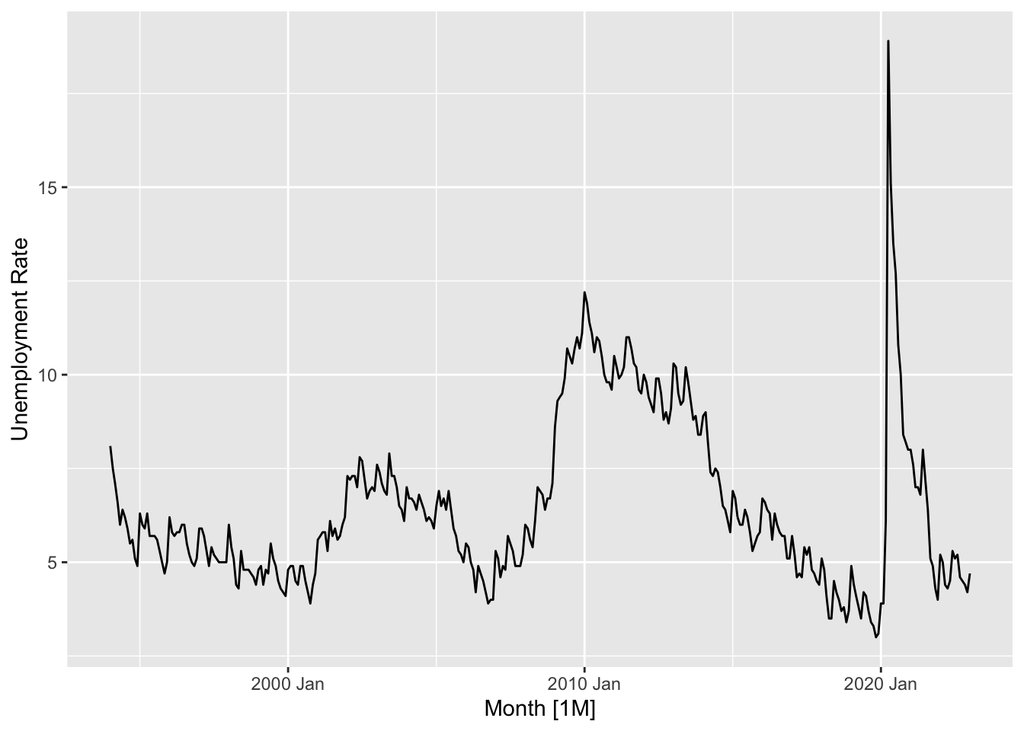

```r
unemployment_chicago %>%
  autoplot(`Unemployment Rate`)
```

## Exploring the Seasonality

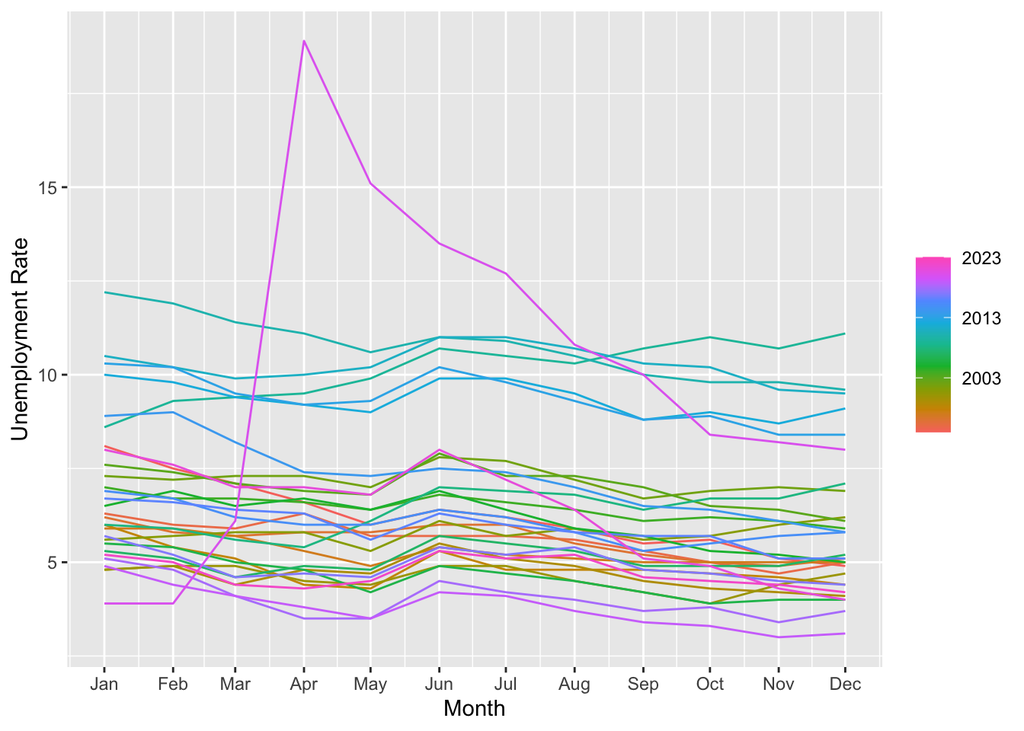

```r
unemployment_chicago %>%
  gg_season(`Unemployment Rate`)
```

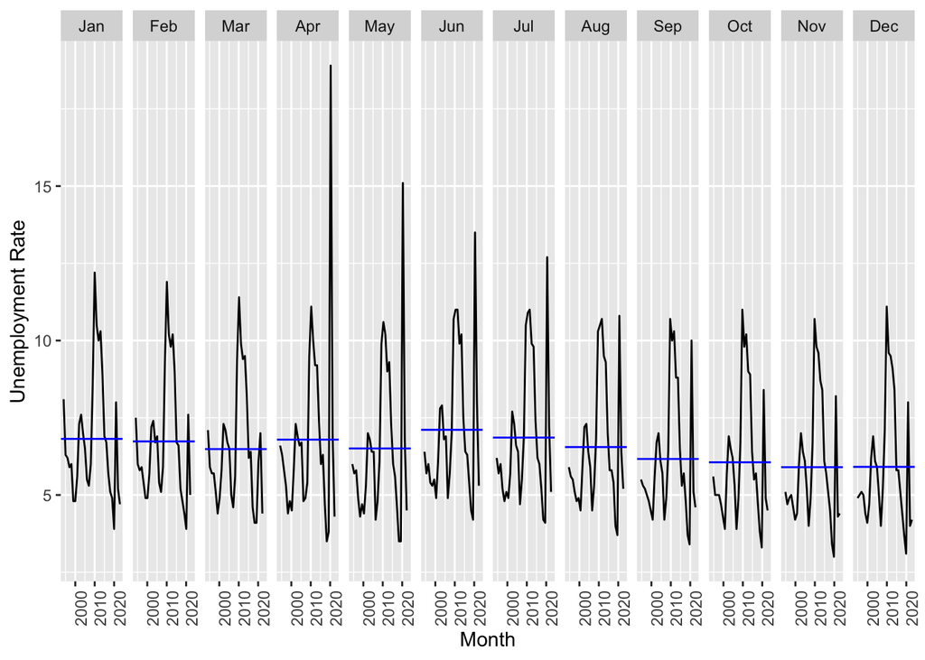

```r
unemployment_chicago %>%
  gg_subseries(`Unemployment Rate`)
```

## STL Decomposition

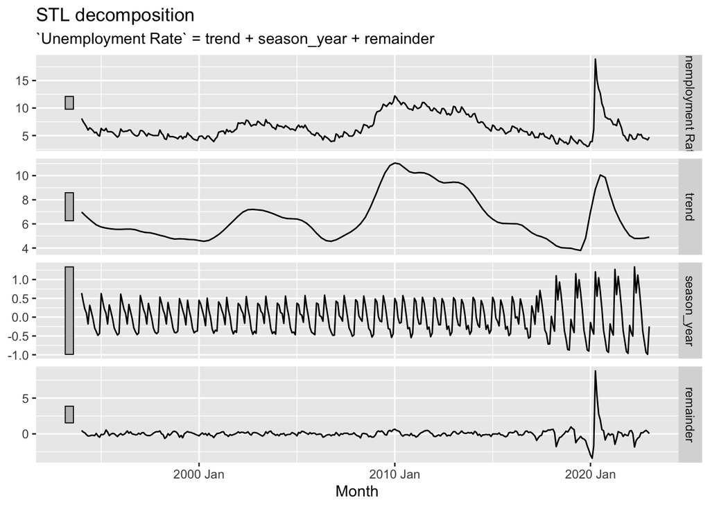

```r
unemployment_chicago %>%
  model (
    STL(`Unemployment Rate`)
  ) %>%
  components() %>%
  autoplot()
```

## Exploring the Autocorrelation

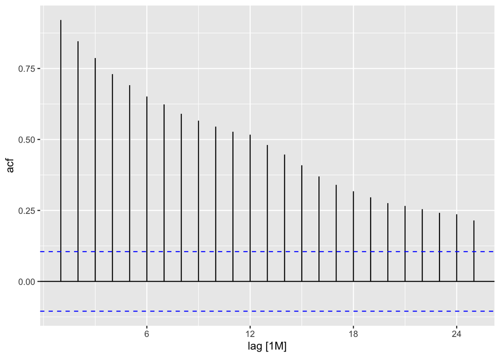

```r
unemployment_chicago %>%
  ACF(`Unemployment Rate`) %>%
  autoplot()
```

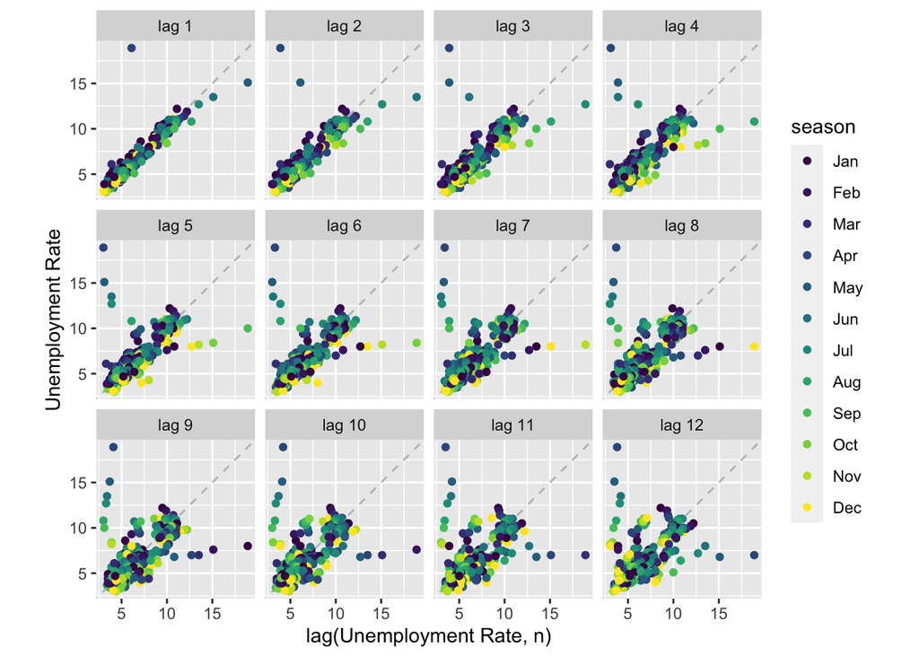

```r
unemployment_chicago %>%
  gg_lag(`Unemployment Rate`, lags = 1:12, geom = "point")
```

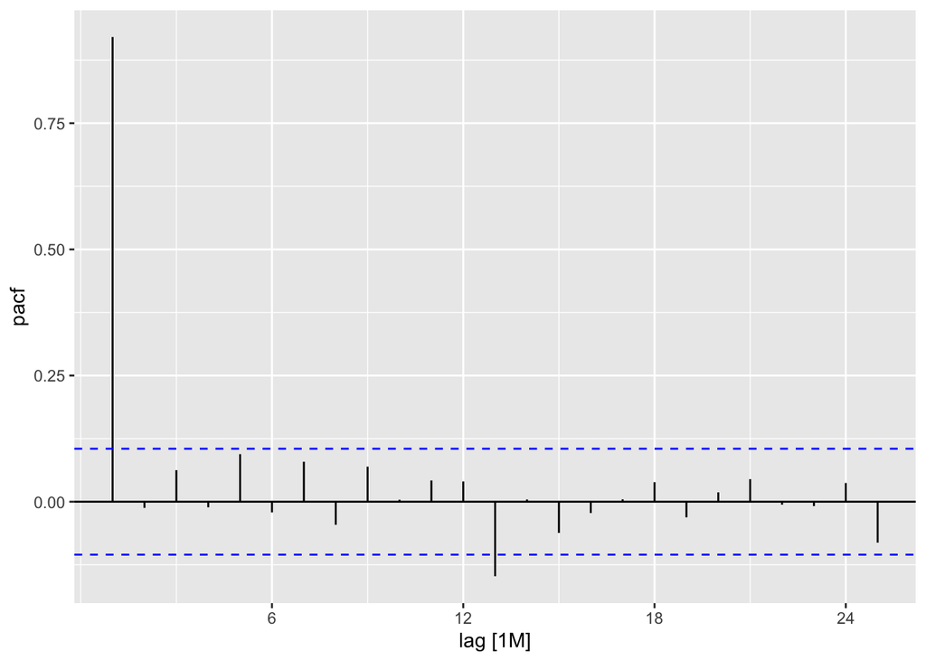

```r
unemployment_chicago %>%
  PACF(`Unemployment Rate`) %>%
  autoplot()
```

# Identifying Appropriate Models

## Box Cox Transformation

```r
unemployment_chicago %>%
  features(`Unemployment Rate`, guerrero)
```

```
## # A tibble: 1 × 1
##   lambda_guerrero
##             <dbl>
## 1          -0.900
```

## Fitting an ARIMA and ETS Model

```r
unemployment_chicago <- unemployment_chicago %>%
  mutate(UnemploymentRate = `Unemployment Rate`)
unemployment_chicago_train <- unemployment_chicago %>%
  filter(year(Month) < 2021)
unemployment.fit <- unemployment_chicago_train %>%
  mutate(UnemploymentRate = `Unemployment Rate`) %>%
  model (
    etsinv = ETS(box_cox(UnemploymentRate, lambda = -1)),
    arimainv = ARIMA(box_cox(UnemploymentRate, lambda = -1)),
    arimaauto = ARIMA(UnemploymentRate),
    etsauto = ETS(UnemploymentRate)
  )
```

### Forecasting: Visualization and Accuracy

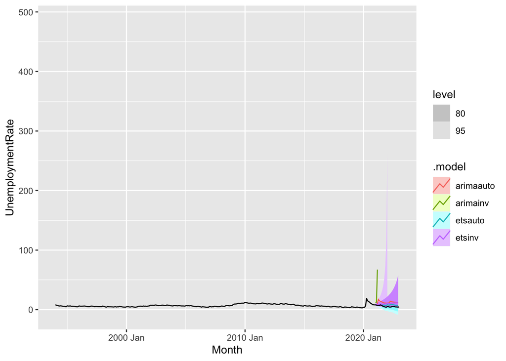

```r
unemployment.fit %>%
  forecast(h = "2 years") %>%
  autoplot(unemployment_chicago)
```

```r
unemployment.fit %>%
  forecast(h = "2 years") %>%
  accuracy(unemployment_chicago)
```

```
## # A tibble: 4 × 10
##   .model    .type     ME  RMSE   MAE    MPE  MAPE  MASE RMSSE   ACF1
##   <chr>     <chr>  <dbl> <dbl> <dbl>  <dbl> <dbl> <dbl> <dbl>  <dbl>
## 1 arimaauto Test   -6.59  6.99  6.59 -130.  130.   5.95  3.62  0.525
## 2 arimainv  Test  -23.0  35.0  23.0  -324.  324.  20.7  18.1  -0.159
## 3 etsauto   Test   -2.34  2.53  2.34  -47.9  47.9  2.11  1.31  0.835
## 4 etsinv    Test   -4.34  4.88  4.34  -90.6  90.6  3.92  2.53  0.843
```

```r
augment(unemployment.fit) %>%
  features(.innov, ljung_box)
```

```
## # A tibble: 4 × 3
##   .model    lb_stat lb_pvalue
##   <chr>       <dbl>     <dbl>
## 1 arimaauto  0.0938   0.759
## 2 arimainv   0.0182   0.893
## 3 etsauto    8.42     0.00371
## 4 etsinv     2.08     0.149
```

Although the ETS model performs the best on the future data, the ETS model appears to have very significant autocorrelation in the residuals of the past data, with a p-value of nearly 0. Further, the prediction intervals for the auto ETS data are very wide, stretching to negative numbers, which does not make sense to interpret in context since unemployment rate should be between 0 and 100%.

### Exploring the Residuals

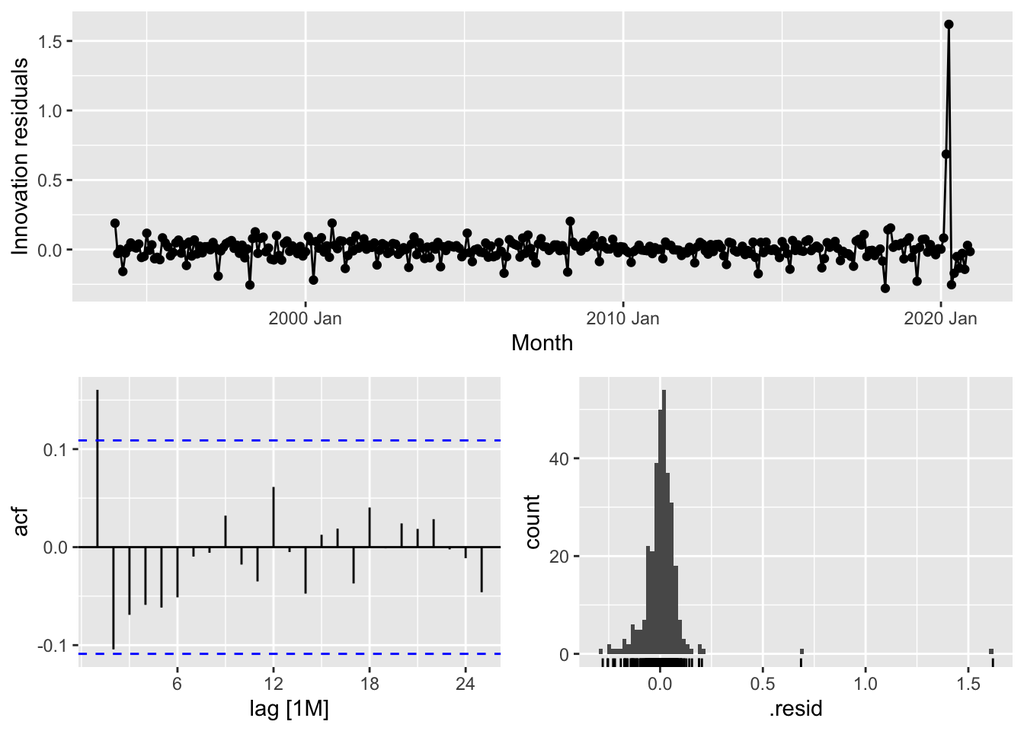

```r
unemployment.fit %>%
  select(etsauto) %>%
  gg_tsresiduals()
```

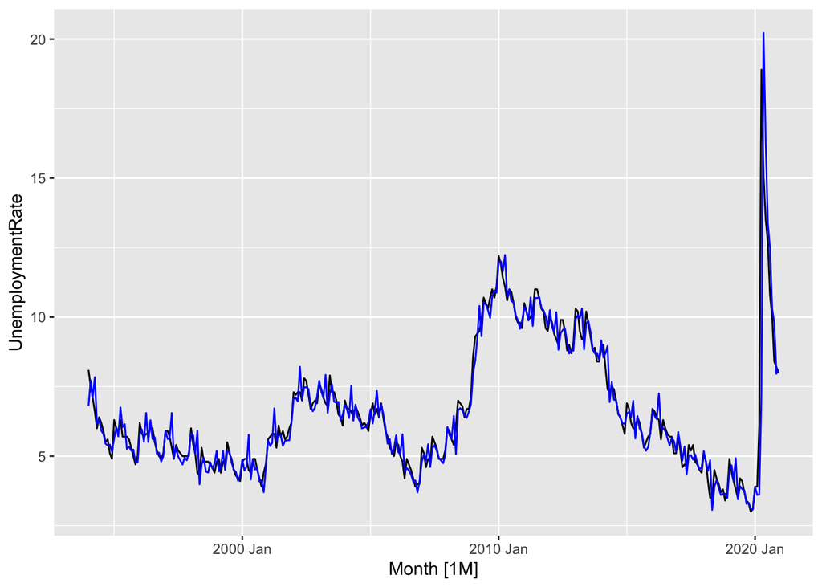

```r
unemployment.fit %>%
  select(etsauto) %>%
  augment() %>%
  autoplot(UnemploymentRate) + geom_line(aes(y = .fitted), color = "blue")
```

The ACF plot of the residuals of the automatically selected ETS model shows one very significant autocorrelation, and one borderline not statistically significant autocorrelation.

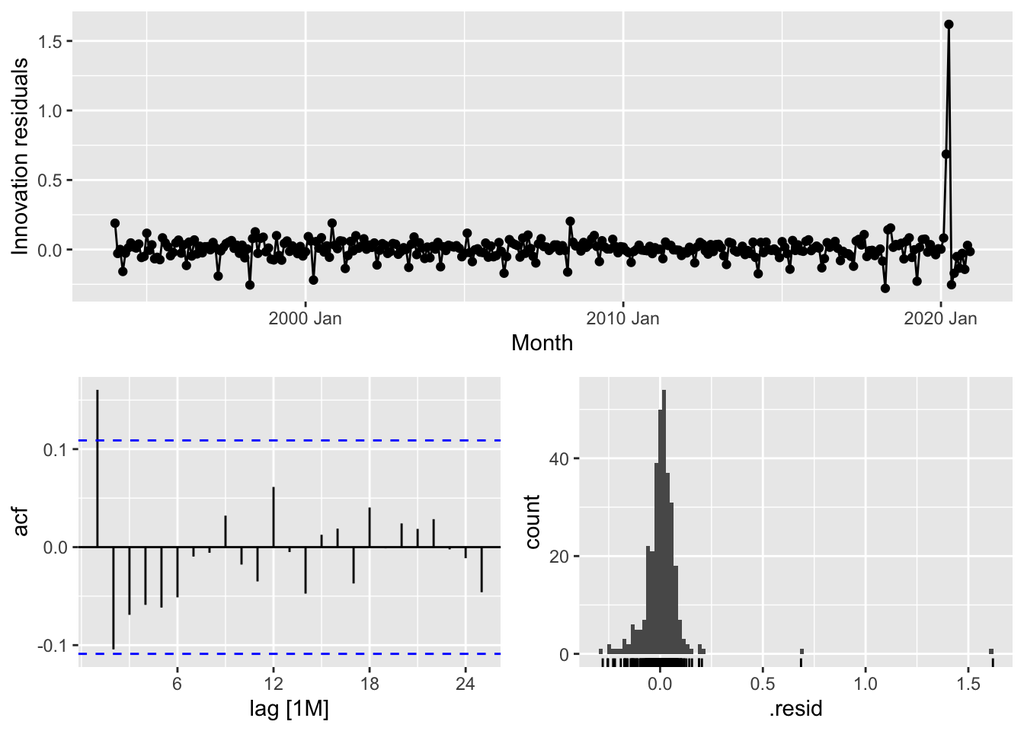

```r
unemployment.fit %>%
  select(etsauto) %>%
  gg_tsresiduals()
```

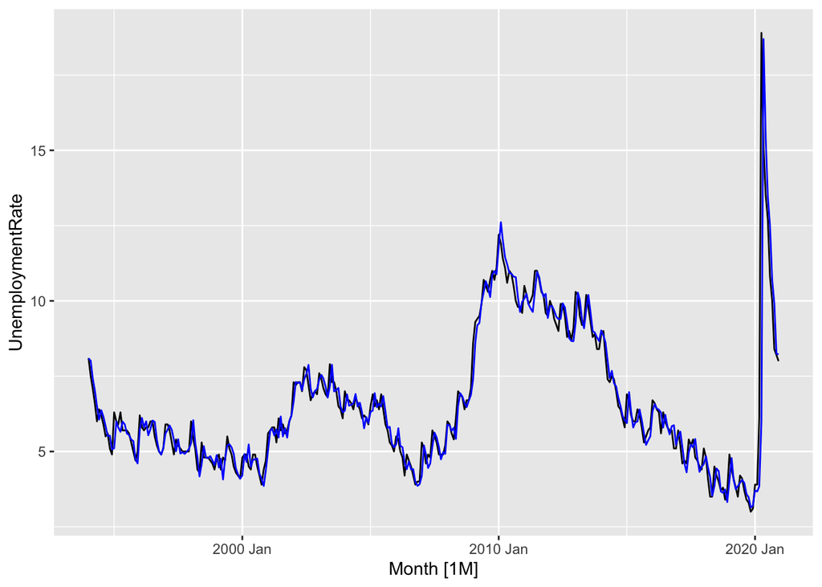

```r
unemployment.fit %>%
  select(arimaauto) %>%
  augment() %>%
  autoplot(UnemploymentRate) + geom_line(aes(y = .fitted), color = "blue")
```

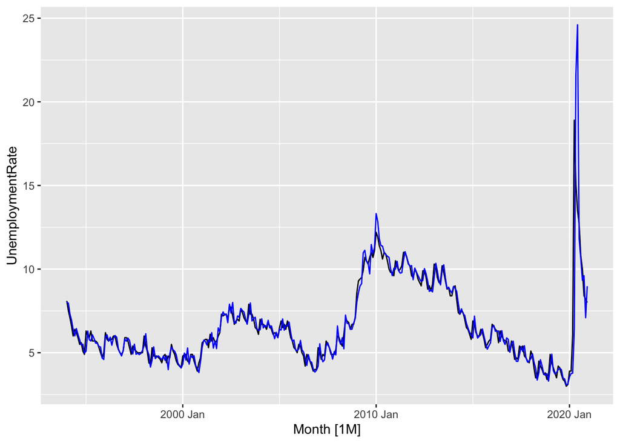

```r
unemployment.fit %>%
  select(arimainv) %>%
  augment() %>%
  autoplot(UnemploymentRate) + geom_line(aes(y = .fitted), color = "blue")
```

```r
unemployment.fit
```

```
## # A mable: 1 x 4
##         etsinv                  arimainv                 arimaauto       etsauto
##        <model>                   <model>                   <model>       <model>
## 1 <ETS(A,N,N)> <ARIMA(0,1,1)(1,0,0)[12]> <ARIMA(0,1,0)(0,0,2)[12]> <ETS(M,Ad,A)>
```

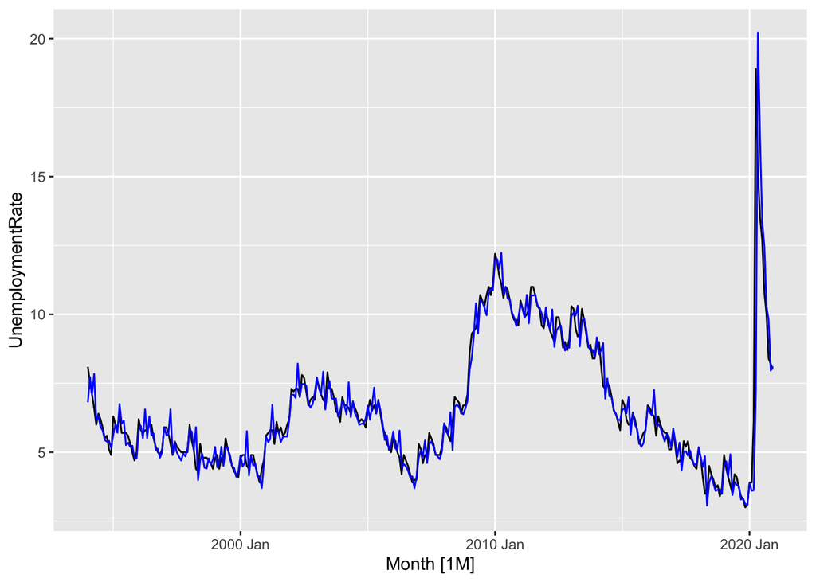

```r
unemployment.fit %>%
  select(etsauto) %>%
  augment() %>%
  autoplot(UnemploymentRate) + geom_line(aes(y = .fitted), color = "blue")
```

# Conclusions and Future Work

In conclusion, the pandemic drastically changed the unemployment rate in Chicago. Although the ARIMA model was able to capture the past data, it failed to predict future data. The ETS model was closer to the actual data because its default predictions were lower than the ARIMA model, but the ARIMA model overall captured the unemployment data better. The inverse transformation did not improve the results for this particular dataset and in fact, the prediction intervals faired worse because of it.

However, there are some ways to get around that. Future work may include using a piecewise function for the dataset so that the years that the pandemic happened and/or other recessions are considered separately from other years. An issue with this data is that while cyclic recessions are indeed accounted for in other years, the pandemic had a much more drastic effect so that the models struggled to adapt. Additionally, I may consider using an indicator variable for the pandemic and/or other recessions, since in this case it was clear that the cause of the peak in unemployment was related to the pandemic.

Additionally, cross validation on the data exploration may improve the results somewhat since it’s easier to predict data less far into the future, but even so, the changes with respect to the pandemic were pretty drastic and the models struggle to adapt.